# Replication Paper:Ritter, Emily H. and Courtenay R. Conrad (2016)

Vlad Surdea-Hernea

## 1. Review of the Paper

**Ritter, Emily H. and Courtenay R. Conrad (2016). Preventing and Responding to Dissent: The Observational Challenges of Explaining Strategic Repression.American Political Science Review.**

### 1.1. Central Argument

#### 1.1.1 Summary of the Theoretical Discussion

Through their paper, **Conrad and Ritter (2016)** challenge the scholarly consensus stating that dissent is the causal determinant of repression, labelled the ‘Law of Coercive Responsiveness’. **The central point of contention has to do with the endogeneity existing in the relationship between citizen dissent and state repression**, both behaviours being strategic and taking into account the anticipated response of the other stakeholder. This complex strategic dynamic creates issues when trying to use existing data to analyse the relationship, as **the direction of the causal relation is uncertain**.

There are two hypotheses put forwards by the authors:

**Hypothesis 1:** When a government has engaged in preventive repression, an increase in manifest dissent will not be associated an increase in responsive repression.

**Hypothesis 2:** When a government has not engaged in preventive repression, an increase in manifest dissent will be associated with an increase in responsive repression.

Once accounting for endogeneity through the usage of an instrumental variable, Conrad and Ritter find that **the relationship between dissent and repression is conditional on regime type**, holding primarily for democratic governments, which engage in reactive/responsive forms of repression:

- **In democracies**, *increases in dissent lead to increases in repression*.

Authoritarian regimes, in contrast, are more adept at using pre-emptive repression, they address threats when opposition is still trying to mobilize, before overt collective action ever actually takes place:

- **In non-democracies**, *increases in dissent do not necessarily lead to increases in repression*.

### 1.2. Data

#### 1.2.1. Data Generation and Collection

- The paper draws it data from examining protest events in 620 US cities every day over 35 years and daily dissent events in 1159 provinces across 54 African countries from 1990 to 2012. These information were collected from The Social Conflict Analysis Database (SCAD) and the Dynamics of Collective Action (DCA) Data Project.
- Events are generated using Associated Press and Agence France Presse newswires.
- For estimates of rainfall in Africa the authors appeal to The U.S. National Oceanic and Atmospheric Administration (NOAA), through their project Africa Rainfall Estimate Climatology (ARC2). Lastly, the geographic coordinates are taken from the Global Administrative Layers or GAUL24 dataset.
- Rainfall data in the U.S. come from the U.S. Historical Climatology Network (USHCN), a subset of the U.S. Cooperative Observer Network, which is operated by NOAA’sNationalWeather Service (NWS).
- For measures of urbanization, the papers uses the Global Rural-Urban Mapping Project (Schneider, Friedl, and Potere 2009; 2010)

#### 1.2.1. Potential Errors

- The data are structured by the province-day in Africa and the state-day in the United States in order to avoid issue like “rain occurring in January—or worse, November—has a meaningful effect on the likelihood of dissent in June”. However, this argument is not fully convincing: in the case of long-lasting dissenting organizations, the yearly non-spontaneous protest schedule is determined in advance as to avoid drought season, monsoon season, etc. **This will be addressed in the extension part**.
- Furthemore, they want to prevent “rainfall occurring in the east could appear to depress protest in the west”; again, this is not very convincing, as in agragrian societies the impact of rain on transport routes for large national dissent groups affects the development of dissent in all parts of the country.
- Lastly, there are issues with the measurement of rainfall in African countries, which might lead to endogeneity problems. Measurement errors are associates with the regime type, which is in turn associated with the levels of repression (Sarojini, Stott, and Black 2016)

### 1.3. Empirical Strategy

#### 1.3.1. Operationalization and Model Specification

- **Mobilized Dissent** is the total number of the following events occurring in a given province day.
- **State Repression** is the total number of events in which the government responds to dissent with repression, regardless of the severity of the action. This count only includes responsive repression.
- **Log of Rainfall** is used as an instrument. The choice for using the log has to due with the level of sensitivity of people to precipitatios:“six inches of rainfall may be equally deterrent as eight”.
- **Percent of Annual Rainfall** is included as a second instrument, capturing what percent the daily amount of rainfall represents for a province in a given year, capturing seasonality and regional variation.
- **Latent Democracy** is used as a control variable. This is a measure that operationalizes institutional constraints as a proxy measurement of the ability to engage in preventive repression.
- **Urbanization** is used as a control variable. This has to do with the fact that it might be easier to protest in localities that have a better infrastructure allowing for collective action, as well as being more easy for authorities to send agent in the field when the problem of transport and resource management is not that relevant.

#### 1.3.2. Instrumental Variable Regression Design

Ritter and Conrad(2016) estimate the effect of dissent on repression using an instrumental variable regression approach to model the effects of unobservable censoring processes. Basically, people are less prone to join a protest or riot if it is raining. The authors also argue that even though rainfall can dissuade dissenters, rainfall is exogenous to repression. Repression is carried out under authoritative orders to contain threat regardless of the weather, and is only related to rainfall through rain’s effect on dissent, not via alternative routes.

Thus, rainfall is a potentially ideal instrument for identifying the causal relationship between dissent and repression because precipitation affects the likelihood of individuals to dissent and does not affect the likelihood of repression given any particular expectation of dissent.

This identification strategy allows the authors to model the assignment of dissent, replacing values of the endogenous dissent with estimates of its exogenous counterpart, echoing a stochastic process.

I will offer a more comprehensive discussion of “rainfall” as the panacea for endogeneity in the last part of the replication paper, when probing robustness. However, I have to mention that whenever we use an IV we should check the following assumptions:

- Relevance, or nonzero average encouragement (first stage) effect, meaning that the instrument $Z$ must create variation in the variable $D$.
- Exogeneity/Ignorability of the instrument, meaning that potential treatments and outcomes independent of the instrument $Z$. This should hold true is rainfall is random, however the predictable patterns of rainfall and extreme weather in Africa are changing in a predictible manner. Moreover, as states in 1.2.1, there are potential issues with the measurement of rainfall which might conflict with the randomness of the assignment. However, for the purpose of the paper, rain appears to act “as-if-random”.
- Exclusion restriction, meaning the instrument $Z$ affects outcome only via treatment. This will be the subject of the entire extension part of the replication paper, but there are serious doubts about this.
- Monotonicity, meaning there are no defiers, groups that would not dissent on sunny days but would dissent on rainy days and vice-versa. While this seems plausinble, there should be further cheks about the existence of groups that would normally not protest, but anticipating that the size of protest would get smaller during rainy days, would get out to support the remaining groups.

#### 1.3.3. Matched Sample Design

- Due to the potential of the results to be determined by the slow change in institutional capacities, as well as by the slow change in the level of urbanization, the authors also use a matched sample that targets this potential issue.
- Coarsened exact matching is used to create a sample of province-days that do and do not experience rainfall paired to have balance on all the other covariates.

## 2. Replication of Table 1

The replication of Table 1 is rather straight-forward. The steps I followed in the code are : merging datasets, selecting variables of use, creating new variables for the OLS and 2SLS regressions, then creating the matched dataset. After this, we just run the OLS and 2SLS regression using the **ivreg** package, summarizing the results and displaying them via the **stargazer** package. The one challenge is using a similar kernel with the one used by the authors for the coarsened exact matching , but the **cem** package offers very good solutions.

### 2.1. Code

```r
library(dplyr)
library(miceadds)
library(mice)
library(tidyr)
library(prettydoc)
library(ggplot2)
library(ggthemes)
library(stargazer)
library(AER)
library(cem)
library(MatchIt)
library(sandwich)
library(rmarkdown)
library(plm)

setwd("/Users/mediagalaxy/Desktop/Replication")

robustSE <- function(data){ sqrt(diag(vcovHC(data, type = "HC")))}

latent <- load.Rdata2( filename="Latent_Democracy.RData")
APSR <- load.Rdata2( filename="RC_APSR_Data.RData")
QoGData <-load.Rdata2( filename="QoGData.RData")

# Merge datasets
APSR <- APSR[order(APSR$cow, APSR$year),]
APSR <- merge(APSR,latent, all = TRUE)
APSR_matching <- merge(APSR,QoGData, all=TRUE)

# Renaming mean to latent_democracy
APSR <- APSR %>% rename(latent_democracy=mean)
APSR_matching <- APSR_matching %>% rename(latent_democracy=mean)

# Generate measures for repression and dissent

APSR$dissentcount <- APSR$etype1+APSR$etype2+APSR$etype3+APSR$etype4+APSR$etype5+APSR$etype6+APSR$etype8+APSR$escalation1+APSR$escalation2+APSR$escalation3+APSR$escalation4+APSR$escalation5+APSR$escalation6+APSR$escalation8

APSR$represscount <- APSR$escalation7+APSR$repBINARYone+APSR$repBINARYtwo;

APSR_matching$dissentcount <- APSR_matching$etype1+APSR_matching$etype2+APSR_matching$etype3+APSR_matching$etype4+APSR_matching$etype5+APSR_matching$etype6+APSR_matching$etype8+APSR_matching$escalation1+APSR_matching$escalation2+APSR_matching$escalation3+APSR_matching$escalation4+APSR_matching$escalation5+APSR_matching$escalation6+APSR_matching$escalation8

APSR_matching$represscount <- APSR_matching$escalation7+APSR_matching$repBINARYone+APSR_matching$repBINARYtwo;

### Drop unnecessary variables
APSR<- subset(APSR, select = -c(etype2, etype3, etype4, etype5, etype6, etype7, etype8, etype9, etype10, escalation0, escalation1, escalation2, escalation3, escalation4, escalation5, escalation6, escalation7, escalation8, escalation9, escalation10, etypeNEG9, repBINARYone, repBINARYtwo, repBINARYzero))

APSR_matching <- subset(APSR_matching, select = -c(etype2, etype3, etype4, etype5, etype6, etype7, etype8, etype9, etype10, escalation0, escalation1, escalation2, escalation3, escalation4, escalation5, escalation6, escalation7, escalation8, escalation9, escalation10, etypeNEG9, repBINARYone, repBINARYtwo, repBINARYzero))

# Generate instrumental variable:

APSR$lograin= log(APSR$rainnonull_mean)

APSR$lograin[is.na(APSR$lograin)] <- 0

APSR$lograin[is.infinite(APSR$lograin)] <- 0

APSR$lograin[is.nan(APSR$lograin)] <- 0

APSR_matching$lograin= log(APSR_matching$rainnonull_mean)

APSR_matching$lograin[is.na(APSR_matching$lograin)] <- 0

APSR_matching$lograin[is.infinite(APSR_matching$lograin)] <- 0

APSR_matching$lograin[is.nan(APSR_matching$lograin)] <- 0

APSR_matching$raintreatment <- ifelse(APSR_matching$lograin<=0, 0, 1)

# Select pre-treatment covariates: urban, population, and wealth; this will be used in the matching process:

names <-  colnames(APSR_matching)[!(colnames(APSR_matching) %in% c("wdi_gdp", "urban_mean", "pop_sum"))]

# Generate matched sample and select weights of variables.

matching_APSR <- cem(treatment = "raintreatment", data = APSR_matching, drop =names)
```

```
FALSE The data contain missing values. CEM will match on them; see the manual for other options.
```

```r
weights <- matching_APSR$w

# Run the basic OLS model

column1<- lm(represscount ~ dissentcount + urban_mean, data=APSR)

# Run the IV model on the entire dataset

column2<- ivreg(represscount ~ dissentcount + urban_mean| urban_mean+ lograin + rainannualpct, data = APSR)

# Run IV models on democratic and non-democratic countries, subseted from the initial dataset
column3<- ivreg(represscount ~ dissentcount + urban_mean| urban_mean+ lograin + rainannualpct, data = APSR, subset= latent_democracy<=0)

column4<- ivreg(represscount ~ dissentcount + urban_mean|urban_mean+ lograin + rainannualpct, data = APSR, subset= latent_democracy>0)

# Run IV models on the matched sample
column6<- ivreg(represscount ~ dissentcount + urban_mean| urban_mean+ lograin + rainannualpct, data =  APSR_matching, subset= latent_democracy>0, weights = weights)
column5<- ivreg(represscount ~ dissentcount + urban_mean| urban_mean+ lograin + rainannualpct, data =  APSR_matching, subset= latent_democracy<=0, weights = weights)

column7 <- ivreg(represscount ~ dissentcount + pop_sum + urban_mean| urban_mean+ lograin + rainannualpct, data =  APSR_matching)

# Compute robust standard errors for Table 1:

robust.se1 <- robustSE(column1)
robust.se2 <- robustSE(column2)
robust.se3 <- robustSE(column3)
robust.se4 <- robustSE(column4)
robust.se5 <- robustSE(column5)
robust.se6 <- robustSE(column6)

summ.column1 <- summary(column1, vcov. = function(x) vcovHC(x, type="HC0"), diagnostics=T)
summ.column2 <- summary(column2, vcov. = function(x) vcovHC(x, type="HC0"), diagnostics=T)
summ.column3 <- summary(column3, vcov. = function(x) vcovHC(x, type="HC0"), diagnostics=T)
summ.column4 <- summary(column4, vcov. = function(x) vcovHC(x, type="HC0"), diagnostics=T)
summ.column5 <- summary(column5, vcov. = function(x) vcovHC(x, type="HC0"), diagnostics=T)
summ.column6 <- summary(column6, vcov. = function(x) vcovHC(x, type="HC0"), diagnostics=T)

# Design the layout of Table 1:

labels = c("<br>1<br> <br>OLS <br>  <br>(No Instrument)", "<br>2<br>  <br>IV Regression<br> <br>(Basic Model)"," <br>3(a)<br>  <br>IV Regression <br>   <br>Non-Democracies","<br> 3(b)<br>  <br>IV Regression  <br>  <br> Democracies","<br>4(a)<br>  <br>Matched IV  Regression <br>  <br>Non-Democracies","<br>4(b)<br>  <br>Matched IV Regression<br>   <br>Democracies")


# Create footnote for Table 1:

notes= c("∗p < 0.05 in two-tailed tests with robust standard errors reported beneath coefficients in parentheses. All analyseswere estimated using R 4.0.0.")


stargazer(column1,column2,column3,column4,column5,column6,
          se=list(robust.se1,robust.se2,robust.se3,robust.se4,robust.se5,robust.se5,robust.se6),
          covariate.labels=c("Mobilized Dissent","Urbanization"),
          title="<b>TABLE 1: The Effect of Mobilized Dissent on State Repression in African Province-Days<b>" ,
          dep.var.labels=c(""),dep.var.caption="",
          column.labels=labels,
          type = "html",
          style="aer",
          out="replicatie10.html",
          model.names = FALSE,
          digits=3,
          digits.extra = 0,
          model.numbers=FALSE,
          notes=notes,
          omit.stat=c("ser","f", "adj.rsq","rsq"),
          star.cutoffs = c(0.05),
          notes.append=FALSE,
          add.lines = list(c("<br>F Test of Excluded Instruments<br>", "<br>-<br>", "<br>28.087 (0.000) <br>", "<br>70.260 (0.000) <br>","<br>73.268 (0.000) <br>","<br>86.127 (0.000) <br>","<br>74.926 (0.000) <br>"),
                           c("<br>Sargan-Hansen J Statistic<br> <br>", "<br>-<br> <br>", "<br>3.604 (0.057) <br> <br>", "<br>0.996 (0.318) <br> <br>", "<br>0.132 (0.616) <br> <br>", "<br>0.873 (0.350) <br> <br>","<br>0.432 (0.501)<br> <br>")))
```

[output not shown]

### 2.2. Table 1

**TABLE 1: The Effect of Mobilized Dissent on State Repression in African Province-Days**

|  | 1 OLS (No Instrument) | 2 IV Regression (Basic Model) | 3(a) IV Regression Non-Democracies | 3(b) IV Regression Democracies | 4(a) Matched IV Regression Non-Democracies | 4(b) Matched IV Regression Democracies |
| --- | --- | --- | --- | --- | --- | --- |
| Mobilized Dissent | 0.233* | -0.087 | 0.010 | 0.269* | -0.028 | 0.253* |
|  | (0.003) | (0.100) | (0.058) | (0.068) | (0.058) | (0.058) |
| Urbanization | -0.007* | -0.009* | -0.009* | -0.006* | -0.008* | -0.006* |
|  | (0.000) | (0.001) | (0.000) | (0.000) | (0.000) | (0.000) |
| Constant | 0.002* | 0.003* | 0.003* | 0.002* | 0.003* | 0.002* |
|  | (0.000) | (0.000) | (0.000) | (0.000) | (0.000) | (0.000) |
| F Test of Excluded Instruments | - | 28.087 (0.000) | 70.260 (0.000) | 73.268 (0.000) | 86.127 (0.000) | 74.926 (0.000) |
| Sargan-Hansen J Statistic | - | 3.604 (0.057) | 0.996 (0.318) | 0.132 (0.616) | 0.873 (0.350) | 0.432 (0.501) |
| Observations | 6,189,005 | 6,083,070 | 4,824,337 | 1,250,335 | 4,824,337 | 1,250,335 |
| *Notes:* | ∗p < 0.05 in two-tailed tests with robust standard errors reported beneath coefficients in parentheses. All analyseswere estimated using R 4.0.0. |  |  |  |  |  |

## 3. Visual Represenation of the Main Arguments

The main argument of the paper is that the relationship between dissent and repression is different in democracies and non-democracies, as when accounting for strategic interactions only democratic regimes tend to use responsive-repression because they did not engage in preventive-repression. This relationship is described in the first plot.

The second plot, which I find as important as the first one, plots the relationship between rainfall and dissent, basically showing that rainfall indeed captures large variations in dissent levels. While this might not be central for the theoretical argument of the paper, it’s important from a methodological perspective, as it allows us to see that indeed, rainfall has the potential to be used as an IV.

### 3.1. Relationship between dissent and repression

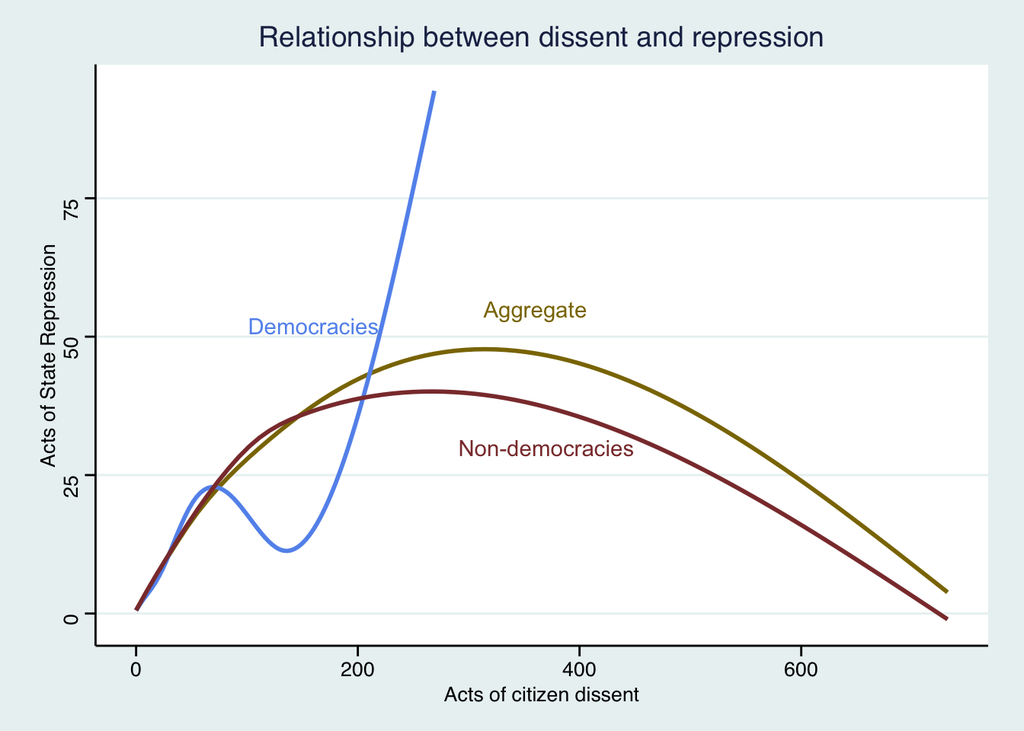

```r
ggplot()+
geom_smooth(data=APSR_plot,aes(x=dissent,y=repress),color="gold4",se=FALSE)+
geom_smooth(data=APSR_plot_democracies,aes(x=dissent,y=repress), color="cornflowerblue",se=FALSE)+
geom_smooth(data=APSR_plot_nondemocracies,aes(x=dissent,y=repress), color="indianred4",se=FALSE)+
  theme_stata()+
  labs(title="Relationship between dissent and repression", x = "Acts of citizen dissent", y = "Acts of State Repression")+
annotate(geom="text", x=370, y=30, label="Non-democracies",color="indianred4")+
annotate(geom="text", x=160, y=52, label="Democracies",color="cornflowerblue")+
annotate(geom="text", x=360, y=55, label="Aggregate",color="gold4")
```

### 3.3. Relationship between rainfall and dissent

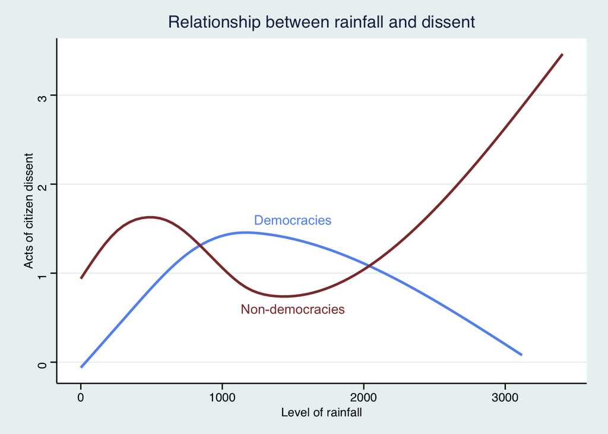

```r
ggplot()+
  geom_smooth(data=APSR_plot_democracies,aes(x=rain,y=dissent), color="cornflowerblue",se=FALSE)+
  geom_smooth(data=APSR_plot_nondemocracies,aes(x=rain,y=dissent), color="indianred4",se=FALSE)+
 theme_stata()+
labs(title="Relationship between rainfall and dissent", x = "Level of rainfall", y = "Acts of citizen dissent")+
annotate(geom="text", x=1500, y=0.6, label="Non-democracies",color="indianred4")+
annotate(geom="text", x=1500, y=1.6, label="Democracies",color="cornflowerblue")
```

## 4.Robustness Check

### 4.1. Theoretical Approach

Since the publication in 2004 of **Economic Shocks and Civil Conflict: An Instrumental Variables Approach** by Edward Miguel, Shanker Satyanath, and Ernest Sergenti, rainfall has become of the preferred instruments, especially when using data related to predominantly agrarian societies such as the ones displayed in large regions of Africa or South Asia.

However, the validity of rainfall as an instrument has been challenged in recent years. Sarsons(2013)shows in a landmark paper studying the relationship between income, instrumentalized through rainfall, and conflict, that rainfall influences the dependent variable through other potential channels, thus being invalid as an instrument. Ritter and Conrad(2016) use rainfall as an instrument for dissent, studying the relationship between dissent and repression. The main theoretical unchecked assumption is that the only channel through which rainfall affects repression is through lowering or augmenting dissent, as people might be more or less prone to protest in relation to the weather. However, there are other potential channels through which rainfall might affect repression:

1. In largely agrarian societies, rainfall is an essential indicator of the annual crop potential and thus of the overall level of agriculture. As such, rainfall is a determinant of economic growth (Collier and Gunning 1999, Miguel et. al 2004, Barrios et. al 2010) . It has been proven that the level of economic growth is associated with a different levels of authoritarianism, and thus with different levels of repression – to be noted that these relations are also potentially endogenous (Przeworski and Limongi 1993). If we would show that rainfall influences economic growth, we should cast suspicions on the validity of rainfall as an instrument for dissent, as rainfall might lead to a change in the preferences of individuals, leading to a different government structure and to different levels of repression.
2. Again, in largely agrarian societies, extreme variations in rainfall, becoming more common due to climate change (Collier et.al 2008, Otto et. al 2015 ), potentially lead to a shift in the distribution of the population between region and countries ( Le Bland and Perez 2007, ECFR 2012). The resulting differences in population density are another potential channel of influencing the levels of repression: given the limited resources of state authorities, repression is more often than not targeted at protests that are political relevant, and thus not often happening in areas with lower densities (Diehl and Gleditsch 2001,Acemoglu et. al 2014)

The extension part of the paper will follow Miguel et al.(2004) in assessing robustness of a 2LS regression by testing for the existence of possible alternative routes from the instrument of choice to the outcome of interest. In this case, I will look if rain influences repression through economic growth(proxied through population), as well as if rain influences repression through political impact of dissent(proxied throug population density)

On thing that needs to be noted is that I will annualize the rainfall variable, so that we see the impact of yearly weather on repression and dissent. While the authors explain how “rain in November doesn’t affect dissent in July”, this seems like a verbal shortcut they use in order to justify the randomness of rainfall. Nevertheless, in many regions of Africa rain patterns are a determinant of human activity, including protests, which might be scheduled as to avoid drought periods in order to maximize human presence.

Lastly, I will use simple OLS regressions to test for robustness in the first place, as well as LSDV regression in order to account for time-fixed or unit-fixed effects of the different tests, benefiting from the variety of data in the given dataset.

### 4.2. Code

```r
APSR_robust <- APSR %>% group_by(adm0_adm1,year) %>%
  summarize(rainmean=mean(annualrainsum), popmean=mean(pop_sum), repressmean=mean(represscount), urbanmean=mean(urban_mean),rainsum=sum(annualrainsum),represssum=sum(represscount), density=mean(pop_sum/provincearea), democracy=mean(latent_democracy) )

APSR_robust <- na.omit(APSR_robust)


# Analyze if rain is a determinant of population

column_robust1 <- lm(popmean~ rainmean, data = APSR_robust)

column_robust2 <- lm(popmean~ rainsum, data = APSR_robust)



#Analyze if populatios, as a proxy for economic growth, influences state sanctioned repression.

column_robust3 <- lm(represssum~ popmean, data = APSR_robust)

column_robust4 <- lm(represssum~ popmean+ rainsum +urbanmean, data = APSR_robust)

lsdv1 <- plm(represssum ~ popmean, data = APSR_robust, index = c("year"),  model = "within", effect = "time")


# Analyze if rain is a determinant of density

column_robust6 <- lm(density~ rainsum, data = APSR_robust)

column_robust9 <- lm(density~ rainmean, data = APSR_robust)


#Analyze if density influences state sanctioned repression.

column_robust7 <- lm(represssum~ density, data = APSR_robust)

column_robust8 <- lm(represssum~ density+ rainsum +urbanmean, data = APSR_robust)

lsdv2 <- plm(represssum ~ density, data = APSR_robust, index = c("year"),  model = "within", effect = "time")
```

### 4.3. Table

**TABLE 2: Robustness Checks**

[output not shown]

### 4.4 Interpretation

However, the larger literature suggests that both economic growth and political relevance of dissent are strong predictos of repression levels. Combined with out proven links between these two variable(potential, after being operationalized) with our finding regarding the influence of rain patterns(the reason for annualization) on them, further research should definitely be pursued as to assess the actual relation between dissent and repression.

As such, the results of my extension part suggest two thing:

1. The given datatset is insufficient for comprehensively testing the robusntess of the results.
2. The usage of rainfall as an instrumental variable is convenient, and the dataset can be wrangled with as to prove its prediction poweer, yet the results are not in line with other strongly supported theoretical finding.

## 4.Bibliography

Acemoglu, Daron & Naidu, Suresh & Robinson,James (2014). “Democracy Does Cause Growth,” NBER Working Papers 20004

Balan Sarojini, B., Stott, P. A. and Black, E. (2016) “Detection and attribution of human influence on regional precipitation”. Nature Climate Change, 6 (7). pp. 669-675

Barrios,Salvador & Bertinelli,Luisito & Strobl, Eric (2010). “Trends in Rainfall and Economic Growth in Africa: A Neglected Cause of the African Growth Tragedy,” The Review of Economics and Statistics, vol. 92(2), 350-366,

Blanc, David Le, and Romain Perez(2008) “The Relationship between Rainfall and Human Density and Its Implications for Future Water Stress in Sub-Saharan Africa.” Ecological Economics, vol. 66, no. 2-3, pp. 319–336.

Collier,Paul &Gunning, Jan Willem (1999). “Why Has Africa Grown Slowly?,” Journal of Economic Perspectives, American Economic Association, vol. 13(3),3-22

Collier, Paul, & Venables, T. (2008). “Climate change and Africa” Oxford Review of Economic Policy, vol. 24, 337–353.

Diehl, Paul F. and Nils Petter Gleditsch (eds.) 2001. Environmental Conflict. Boulder, CO: Westview.

Miguel,Edward & Shanker,Satyanath & Ernest Sergenti (2004). “Economic Shocks and Civil Conflict: An Instrumental Variables Approach,” Journal of Political Economy, University of Chicago Press, vol. 112(4), 725-753,

Otto, Frederick (2018).“Climate change increases the probability of heavy rains in Northern England/Southern Scotland like those of storm Desmond—a real-time event attribution revisited” Environmental Research Letters, vol.13

Przeworski, Adam & Limongi,Fernando (1993). “Political Regimes and Economic Growth,” Journal of Economic Perspectives, American Economic Association, vol. 7(3), 51-69

Sarsons H. (2015) “Rainfall and Conflict: A Cautionary Tale”. Journal of Development Economics. vol. 115 :62-72.